# Kmeans Using Pyspark

MLlib Kmeans: https://spark.apache.org/docs/latest/api/python/reference/api/pyspark.ml.clustering.KMeans.html

```python
Name: Monier Ashraf Monier Lawande
ID: 221002188
```

```python
from pyspark.sql import SparkSession
from pyspark.ml.clustering import KMeans
from pyspark.ml.linalg import Vectors
import pandas as pd
import matplotlib.pyplot as plt
from mpl_toolkits.mplot3d import Axes3D
from pyspark.ml.feature import VectorAssembler
from pyspark.sql import functions as F
```

```python
spark = SparkSession.builder.appName("Spark Examples").getOrCreate()
```

The dataset consists of information about customers Visiting a mall

- problem: Cluster customers into segments

```python
df = spark.read.csv('customers.csv', header=True)
df.show()
```

```
+---+------+--------+----------+
| id|Income|Spending|Birth Year|
+---+------+--------+----------+
|  1|    15|      39|      2004|
|  2|    15|      81|      2002|
|  3|    16|       6|      2003|
|  4|    16|      77|      2000|
|  5|    17|      40|      1992|
|  6|    17|      76|      2001|
|  7|    18|       6|      1988|
|  8|    18|      94|      2000|
|  9|    19|       3|      1959|
| 10|    19|      72|      1993|
| 11|    19|      14|      1956|
| 12|    19|      99|      1988|
| 13|    20|      15|      1965|
| 14|    20|      77|      1999|
| 15|    20|      13|      1986|
| 16|    20|      79|      2001|
| 17|    21|      35|      1988|
| 18|    21|      66|      2003|
| 19|    23|      29|      1971|
| 20|    23|      98|      1988|
+---+------+--------+----------+
only showing top 20 rows
```

Spark's implementation of KMeans is a bit different from for example scikit-learn's version. We need to store all features as an array of floats, and store this array as a column called "features". Since we do no longer need the original columns we filter them out with a select statement.

- "features" column: Vector of your dataset features

```python
FEATURES_COL = ['Income','Spending','Birth Year']
```

```python
df.schema
```

```
StructType(List(StructField(id,StringType,true),StructField(Income,StringType,true),StructField(Spending,StringType,true),StructField(Birth Year,StringType,true)))
```

```python
for col in FEATURES_COL:
  df = df.withColumn(col,df[col].cast('int'))
df.show()
```

```
+---+------+--------+----------+
| id|Income|Spending|Birth Year|
+---+------+--------+----------+
|  1|    15|      39|      2004|
|  2|    15|      81|      2002|
|  3|    16|       6|      2003|
|  4|    16|      77|      2000|
|  5|    17|      40|      1992|
|  6|    17|      76|      2001|
|  7|    18|       6|      1988|
|  8|    18|      94|      2000|
|  9|    19|       3|      1959|
| 10|    19|      72|      1993|
| 11|    19|      14|      1956|
| 12|    19|      99|      1988|
| 13|    20|      15|      1965|
| 14|    20|      77|      1999|
| 15|    20|      13|      1986|
| 16|    20|      79|      2001|
| 17|    21|      35|      1988|
| 18|    21|      66|      2003|
| 19|    23|      29|      1971|
| 20|    23|      98|      1988|
+---+------+--------+----------+
only showing top 20 rows
```

```python
df.schema
```

```
StructType(List(StructField(id,StringType,true),StructField(Income,IntegerType,true),StructField(Spending,IntegerType,true),StructField(Birth Year,IntegerType,true)))
```

**Now Create a features column**

```python
Feautes_Assembler = VectorAssembler(inputCols=FEATURES_COL, outputCol="features")
df_kmeans = Feautes_Assembler.transform(df)
df_kmeans.show()
```

```
+---+------+--------+----------+------------------+
| id|Income|Spending|Birth Year|          features|
+---+------+--------+----------+------------------+
|  1|    15|      39|      2004|[15.0,39.0,2004.0]|
|  2|    15|      81|      2002|[15.0,81.0,2002.0]|
|  3|    16|       6|      2003| [16.0,6.0,2003.0]|
|  4|    16|      77|      2000|[16.0,77.0,2000.0]|
|  5|    17|      40|      1992|[17.0,40.0,1992.0]|
|  6|    17|      76|      2001|[17.0,76.0,2001.0]|
|  7|    18|       6|      1988| [18.0,6.0,1988.0]|
|  8|    18|      94|      2000|[18.0,94.0,2000.0]|
|  9|    19|       3|      1959| [19.0,3.0,1959.0]|
| 10|    19|      72|      1993|[19.0,72.0,1993.0]|
| 11|    19|      14|      1956|[19.0,14.0,1956.0]|
| 12|    19|      99|      1988|[19.0,99.0,1988.0]|
| 13|    20|      15|      1965|[20.0,15.0,1965.0]|
| 14|    20|      77|      1999|[20.0,77.0,1999.0]|
| 15|    20|      13|      1986|[20.0,13.0,1986.0]|
| 16|    20|      79|      2001|[20.0,79.0,2001.0]|
| 17|    21|      35|      1988|[21.0,35.0,1988.0]|
| 18|    21|      66|      2003|[21.0,66.0,2003.0]|
| 19|    23|      29|      1971|[23.0,29.0,1971.0]|
| 20|    23|      98|      1988|[23.0,98.0,1988.0]|
+---+------+--------+----------+------------------+
only showing top 20 rows
```

```python
df_kmeans = df_kmeans.select("id",'features')
df_kmeans.show()
```

```
+---+------------------+
| id|          features|
+---+------------------+
|  1|[15.0,39.0,2004.0]|
|  2|[15.0,81.0,2002.0]|
|  3| [16.0,6.0,2003.0]|
|  4|[16.0,77.0,2000.0]|
|  5|[17.0,40.0,1992.0]|
|  6|[17.0,76.0,2001.0]|
|  7| [18.0,6.0,1988.0]|
|  8|[18.0,94.0,2000.0]|
|  9| [19.0,3.0,1959.0]|
| 10|[19.0,72.0,1993.0]|
| 11|[19.0,14.0,1956.0]|
| 12|[19.0,99.0,1988.0]|
| 13|[20.0,15.0,1965.0]|
| 14|[20.0,77.0,1999.0]|
| 15|[20.0,13.0,1986.0]|
| 16|[20.0,79.0,2001.0]|
| 17|[21.0,35.0,1988.0]|
| 18|[21.0,66.0,2003.0]|
| 19|[23.0,29.0,1971.0]|
| 20|[23.0,98.0,1988.0]|
+---+------------------+
only showing top 20 rows
```

**Train The model**

```python
kmeans = KMeans().setK(3).setSeed(1).setMaxIter(500).setFeaturesCol("features")
model = kmeans.fit(df_kmeans)
```

```python
predictions = model.transform(df_kmeans)
```

```python
predictions.show()
```

```
+---+------------------+----------+
| id|          features|prediction|
+---+------------------+----------+
|  1|[15.0,39.0,2004.0]|         1|
|  2|[15.0,81.0,2002.0]|         1|
|  3| [16.0,6.0,2003.0]|         0|
|  4|[16.0,77.0,2000.0]|         1|
|  5|[17.0,40.0,1992.0]|         1|
|  6|[17.0,76.0,2001.0]|         1|
|  7| [18.0,6.0,1988.0]|         0|
|  8|[18.0,94.0,2000.0]|         1|
|  9| [19.0,3.0,1959.0]|         0|
| 10|[19.0,72.0,1993.0]|         1|
| 11|[19.0,14.0,1956.0]|         0|
| 12|[19.0,99.0,1988.0]|         1|
| 13|[20.0,15.0,1965.0]|         0|
| 14|[20.0,77.0,1999.0]|         1|
| 15|[20.0,13.0,1986.0]|         0|
| 16|[20.0,79.0,2001.0]|         1|
| 17|[21.0,35.0,1988.0]|         1|
| 18|[21.0,66.0,2003.0]|         1|
| 19|[23.0,29.0,1971.0]|         0|
| 20|[23.0,98.0,1988.0]|         1|
+---+------------------+----------+
only showing top 20 rows
```

```python
predictions_df = predictions.select("id", "prediction")
```

```python
predictions_df.show(5)
```

```
+---+----------+
| id|prediction|
+---+----------+
|  1|         1|
|  2|         1|
|  3|         0|
|  4|         1|
|  5|         1|
+---+----------+
only showing top 5 rows
```

**Join the prediction column with the your original data using the id column**

```python
df_final_preds = df.join(predictions_df, 'id')
df_final_preds.show()
```

```
+---+------+--------+----------+----------+
| id|Income|Spending|Birth Year|prediction|
+---+------+--------+----------+----------+
|  1|    15|      39|      2004|         1|
|  2|    15|      81|      2002|         1|
|  3|    16|       6|      2003|         0|
|  4|    16|      77|      2000|         1|
|  5|    17|      40|      1992|         1|
|  6|    17|      76|      2001|         1|
|  7|    18|       6|      1988|         0|
|  8|    18|      94|      2000|         1|
|  9|    19|       3|      1959|         0|
| 10|    19|      72|      1993|         1|
| 11|    19|      14|      1956|         0|
| 12|    19|      99|      1988|         1|
| 13|    20|      15|      1965|         0|
| 14|    20|      77|      1999|         1|
| 15|    20|      13|      1986|         0|
| 16|    20|      79|      2001|         1|
| 17|    21|      35|      1988|         1|
| 18|    21|      66|      2003|         1|
| 19|    23|      29|      1971|         0|
| 20|    23|      98|      1988|         1|
+---+------+--------+----------+----------+
only showing top 20 rows
```

**Convert it to pandas df**

```python
preds = df_final_preds.toPandas()
preds.head()
```

|  | id | Income | Spending | Birth Year | prediction |
| --- | --- | --- | --- | --- | --- |
| 0 | 1 | 15 | 39 | 2004 | 1 |
| 1 | 2 | 15 | 81 | 2002 | 1 |
| 2 | 3 | 16 | 6 | 2003 | 0 |
| 3 | 4 | 16 | 77 | 2000 | 1 |
| 4 | 5 | 17 | 40 | 1992 | 1 |

**Visualize Final Clusters**

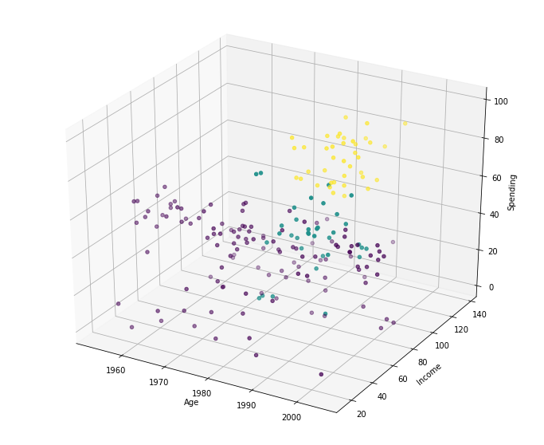

```python
cluster_fig = plt.figure(figsize=(12,10)).gca(projection='3d')
cluster_fig.scatter(preds['Birth Year'],preds['Income'],preds['Spending'], c=preds['prediction'])
cluster_fig.set_xlabel('Age')
cluster_fig.set_ylabel('Income')
cluster_fig.set_zlabel('Spending')
plt.show()
```

### Task 1:

- Implement a Function using Pyspark User Defined Function (UDF) to convert the **Birth Year** Column to a **Age** Column.
- Apply Kmeans Algorithm Again to Compare the results.

```python
def age_fun(Birth_Year):
    age=2023-Birth_Year
    return age
```

```python
age_fun(2000)
```

```
23
```

```python
age_conv = F.udf(age_fun)
```

```python
df_age = df.withColumn("age", age_conv(df["Birth Year"]))
```

```python
df_age.show()
```

```
+---+------+--------+----------+---+
| id|Income|Spending|Birth Year|age|
+---+------+--------+----------+---+
|  1|    15|      39|      2004| 19|
|  2|    15|      81|      2002| 21|
|  3|    16|       6|      2003| 20|
|  4|    16|      77|      2000| 23|
|  5|    17|      40|      1992| 31|
|  6|    17|      76|      2001| 22|
|  7|    18|       6|      1988| 35|
|  8|    18|      94|      2000| 23|
|  9|    19|       3|      1959| 64|
| 10|    19|      72|      1993| 30|
| 11|    19|      14|      1956| 67|
| 12|    19|      99|      1988| 35|
| 13|    20|      15|      1965| 58|
| 14|    20|      77|      1999| 24|
| 15|    20|      13|      1986| 37|
| 16|    20|      79|      2001| 22|
| 17|    21|      35|      1988| 35|
| 18|    21|      66|      2003| 20|
| 19|    23|      29|      1971| 52|
| 20|    23|      98|      1988| 35|
+---+------+--------+----------+---+
only showing top 20 rows
```

```python
df_age.schema
```

```
StructType(List(StructField(id,StringType,true),StructField(Income,IntegerType,true),StructField(Spending,IntegerType,true),StructField(Birth Year,IntegerType,true),StructField(age,StringType,true)))
```

```python
FEATURES_COL2 = ['Income','Spending','age']
```

```python
for col in FEATURES_COL2:
  df_age = df_age.withColumn(col,df_age[col].cast('int'))
df_age.show()
```

```
+---+------+--------+----------+---+
| id|Income|Spending|Birth Year|age|
+---+------+--------+----------+---+
|  1|    15|      39|      2004| 19|
|  2|    15|      81|      2002| 21|
|  3|    16|       6|      2003| 20|
|  4|    16|      77|      2000| 23|
|  5|    17|      40|      1992| 31|
|  6|    17|      76|      2001| 22|
|  7|    18|       6|      1988| 35|
|  8|    18|      94|      2000| 23|
|  9|    19|       3|      1959| 64|
| 10|    19|      72|      1993| 30|
| 11|    19|      14|      1956| 67|
| 12|    19|      99|      1988| 35|
| 13|    20|      15|      1965| 58|
| 14|    20|      77|      1999| 24|
| 15|    20|      13|      1986| 37|
| 16|    20|      79|      2001| 22|
| 17|    21|      35|      1988| 35|
| 18|    21|      66|      2003| 20|
| 19|    23|      29|      1971| 52|
| 20|    23|      98|      1988| 35|
+---+------+--------+----------+---+
only showing top 20 rows
```

```python
Feautes_Assembler2 = VectorAssembler(inputCols=FEATURES_COL2, outputCol="features")
df_kmeans2 = Feautes_Assembler2.transform(df_age)
df_kmeans2.show()
```

```
+---+------+--------+----------+---+----------------+
| id|Income|Spending|Birth Year|age|        features|
+---+------+--------+----------+---+----------------+
|  1|    15|      39|      2004| 19|[15.0,39.0,19.0]|
|  2|    15|      81|      2002| 21|[15.0,81.0,21.0]|
|  3|    16|       6|      2003| 20| [16.0,6.0,20.0]|
|  4|    16|      77|      2000| 23|[16.0,77.0,23.0]|
|  5|    17|      40|      1992| 31|[17.0,40.0,31.0]|
|  6|    17|      76|      2001| 22|[17.0,76.0,22.0]|
|  7|    18|       6|      1988| 35| [18.0,6.0,35.0]|
|  8|    18|      94|      2000| 23|[18.0,94.0,23.0]|
|  9|    19|       3|      1959| 64| [19.0,3.0,64.0]|
| 10|    19|      72|      1993| 30|[19.0,72.0,30.0]|
| 11|    19|      14|      1956| 67|[19.0,14.0,67.0]|
| 12|    19|      99|      1988| 35|[19.0,99.0,35.0]|
| 13|    20|      15|      1965| 58|[20.0,15.0,58.0]|
| 14|    20|      77|      1999| 24|[20.0,77.0,24.0]|
| 15|    20|      13|      1986| 37|[20.0,13.0,37.0]|
| 16|    20|      79|      2001| 22|[20.0,79.0,22.0]|
| 17|    21|      35|      1988| 35|[21.0,35.0,35.0]|
| 18|    21|      66|      2003| 20|[21.0,66.0,20.0]|
| 19|    23|      29|      1971| 52|[23.0,29.0,52.0]|
| 20|    23|      98|      1988| 35|[23.0,98.0,35.0]|
+---+------+--------+----------+---+----------------+
only showing top 20 rows
```

```python
df_kmeans2 = df_kmeans2.select("id",'features')
df_kmeans2.show()
```

```
+---+----------------+
| id|        features|
+---+----------------+
|  1|[15.0,39.0,19.0]|
|  2|[15.0,81.0,21.0]|
|  3| [16.0,6.0,20.0]|
|  4|[16.0,77.0,23.0]|
|  5|[17.0,40.0,31.0]|
|  6|[17.0,76.0,22.0]|
|  7| [18.0,6.0,35.0]|
|  8|[18.0,94.0,23.0]|
|  9| [19.0,3.0,64.0]|
| 10|[19.0,72.0,30.0]|
| 11|[19.0,14.0,67.0]|
| 12|[19.0,99.0,35.0]|
| 13|[20.0,15.0,58.0]|
| 14|[20.0,77.0,24.0]|
| 15|[20.0,13.0,37.0]|
| 16|[20.0,79.0,22.0]|
| 17|[21.0,35.0,35.0]|
| 18|[21.0,66.0,20.0]|
| 19|[23.0,29.0,52.0]|
| 20|[23.0,98.0,35.0]|
+---+----------------+
only showing top 20 rows
```

```python
kmeans2 = KMeans().setK(3).setSeed(1).setMaxIter(500).setFeaturesCol("features")
model2 = kmeans2.fit(df_kmeans2)
```

```python
predictions2 = model2.transform(df_kmeans2)
```

```python
predictions2.show()
```

```
+---+----------------+----------+
| id|        features|prediction|
+---+----------------+----------+
|  1|[15.0,39.0,19.0]|         1|
|  2|[15.0,81.0,21.0]|         1|
|  3| [16.0,6.0,20.0]|         0|
|  4|[16.0,77.0,23.0]|         1|
|  5|[17.0,40.0,31.0]|         1|
|  6|[17.0,76.0,22.0]|         1|
|  7| [18.0,6.0,35.0]|         0|
|  8|[18.0,94.0,23.0]|         1|
|  9| [19.0,3.0,64.0]|         0|
| 10|[19.0,72.0,30.0]|         1|
| 11|[19.0,14.0,67.0]|         0|
| 12|[19.0,99.0,35.0]|         1|
| 13|[20.0,15.0,58.0]|         0|
| 14|[20.0,77.0,24.0]|         1|
| 15|[20.0,13.0,37.0]|         0|
| 16|[20.0,79.0,22.0]|         1|
| 17|[21.0,35.0,35.0]|         1|
| 18|[21.0,66.0,20.0]|         1|
| 19|[23.0,29.0,52.0]|         0|
| 20|[23.0,98.0,35.0]|         1|
+---+----------------+----------+
only showing top 20 rows
```

```python
predictions_df2 = predictions2.select("id", "prediction")
```

```python
predictions_df2.show(5)
```

```
+---+----------+
| id|prediction|
+---+----------+
|  1|         1|
|  2|         1|
|  3|         0|
|  4|         1|
|  5|         1|
+---+----------+
only showing top 5 rows
```

```python
df_final_preds2 = df_age.join(predictions_df2, 'id')
df_final_preds2.show()
```

```
+---+------+--------+----------+---+----------+
| id|Income|Spending|Birth Year|age|prediction|
+---+------+--------+----------+---+----------+
|  1|    15|      39|      2004| 19|         1|
|  2|    15|      81|      2002| 21|         1|
|  3|    16|       6|      2003| 20|         0|
|  4|    16|      77|      2000| 23|         1|
|  5|    17|      40|      1992| 31|         1|
|  6|    17|      76|      2001| 22|         1|
|  7|    18|       6|      1988| 35|         0|
|  8|    18|      94|      2000| 23|         1|
|  9|    19|       3|      1959| 64|         0|
| 10|    19|      72|      1993| 30|         1|
| 11|    19|      14|      1956| 67|         0|
| 12|    19|      99|      1988| 35|         1|
| 13|    20|      15|      1965| 58|         0|
| 14|    20|      77|      1999| 24|         1|
| 15|    20|      13|      1986| 37|         0|
| 16|    20|      79|      2001| 22|         1|
| 17|    21|      35|      1988| 35|         1|
| 18|    21|      66|      2003| 20|         1|
| 19|    23|      29|      1971| 52|         0|
| 20|    23|      98|      1988| 35|         1|
+---+------+--------+----------+---+----------+
only showing top 20 rows
```

```python
preds2 = df_final_preds2.toPandas()
preds2.head()
```

|  | id | Income | Spending | Birth Year | age | prediction |
| --- | --- | --- | --- | --- | --- | --- |
| 0 | 1 | 15 | 39 | 2004 | 19 | 1 |
| 1 | 2 | 15 | 81 | 2002 | 21 | 1 |
| 2 | 3 | 16 | 6 | 2003 | 20 | 0 |
| 3 | 4 | 16 | 77 | 2000 | 23 | 1 |
| 4 | 5 | 17 | 40 | 1992 | 31 | 1 |

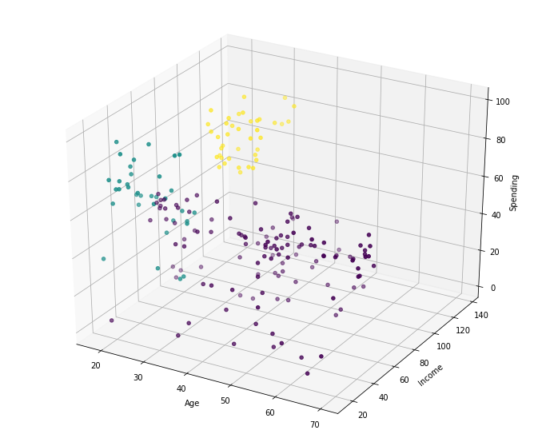

```python
cluster_fig2 = plt.figure(figsize=(12,10)).gca(projection='3d')
cluster_fig2.scatter(preds2["age"],preds2['Income'],preds2['Spending'], c=preds2['prediction'])
cluster_fig2.set_xlabel('Age')
cluster_fig2.set_ylabel('Income')
cluster_fig2.set_zlabel('Spending')
plt.show()
```

# Compare the results

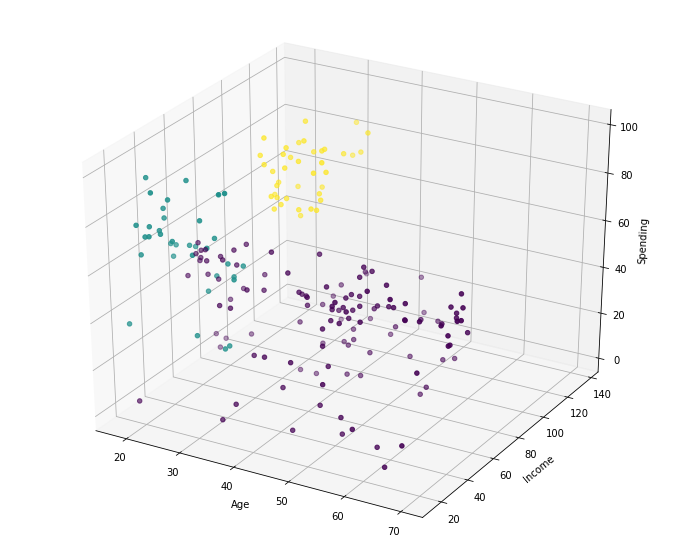

```python
cluster_fig2 = plt.figure(figsize=(12,10)).gca(projection='3d')
cluster_fig2.scatter(preds2["age"],preds2['Income'],preds2['Spending'], c=preds2['prediction'])
cluster_fig2.set_xlabel('Age')
cluster_fig2.set_ylabel('Income')
cluster_fig2.set_zlabel('Spending')
plt.show()
```

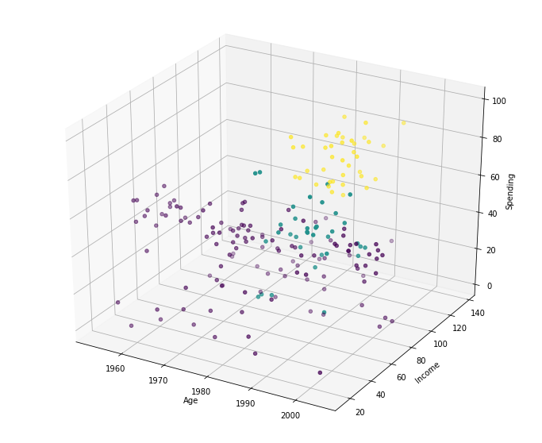

```python
cluster_fig = plt.figure(figsize=(12,10)).gca(projection='3d')
cluster_fig.scatter(preds['Birth Year'],preds['Income'],preds['Spending'], c=preds['prediction'])
cluster_fig.set_xlabel('Age')
cluster_fig.set_ylabel('Income')
cluster_fig.set_zlabel('Spending')
plt.show()
```

### Compare the results

##### -in two senarios have same point approximately

# Pyspark User Defined Functions

- UDF: https://sparkbyexamples.com/pyspark/pyspark-udf-user-defined-function/
- Built in Functions: https://sparkbyexamples.com/spark/spark-sql-functions/

```python
from pyspark.sql import functions as F
import pandas as pd
```

```python
data = spark.read.format("csv")\
            .option("header", "true")\
            .load("Tweets.csv")
```

```python
data.show()
```

```
+-----+--------------------+
|   id|               tweet|
+-----+--------------------+
|31963|#studiolife #aisl...|
|31964| @user #white #su...|
|31965|safe ways to heal...|
|31966|is the hp and the...|
|31967|  3rd #bihday to ...|
|31968|choose to be   :)...|
|31969|something inside ...|
|31970|#finished#tattoo#...|
|31971| @user @user @use...|
|31972|#delicious   #foo...|
|31973|1000dayswasted - ...|
|31974|one of the world'...|
|31975|half way through ...|
|31976|good food, good l...|
|31977|i'll stand behind...|
|31978|i ate,i ate and i...|
|31979| @user got my @us...|
|31980|&amp; #love &amp;...|
|31981|ððð #gir...|
|31982|thought factory: ...|
+-----+--------------------+
only showing top 20 rows
```

**Create a Function to apply word count on tweet column**

```python
def word_count_fn(tweet):
  split_tweet = tweet.split()
  dic_of_words = {}
  for word in split_tweet:
    dic_of_words[word] = split_tweet.count(word)
  return dic_of_words
```

```python
# test Function
word_count_fn("a set of words that is complete in itself, typically containing a subject and predicate, conveying a statement, question, exclamation, or command, and consisting of a main clause and sometimes one or more subordinate clauses.")
```

```
{'a': 4,
 'and': 3,
 'clause': 1,
 'clauses.': 1,
 'command,': 1,
 'complete': 1,
 'consisting': 1,
 'containing': 1,
 'conveying': 1,
 'exclamation,': 1,
 'in': 1,
 'is': 1,
 'itself,': 1,
 'main': 1,
 'more': 1,
 'of': 2,
 'one': 1,
 'or': 2,
 'predicate,': 1,
 'question,': 1,
 'set': 1,
 'sometimes': 1,
 'statement,': 1,
 'subject': 1,
 'subordinate': 1,
 'that': 1,
 'typically': 1,
 'words': 1}
```

```python
# Convert your Python function to PySpark UDF (User defined Function)
countWords = F.udf(word_count_fn)
```

```python
# Now add the new column to your Dataframe
data = data.withColumn("WordCount", countWords(data.tweet))
```

```python
data.show()
```

```
+-----+--------------------+--------------------+
|   id|               tweet|           WordCount|
+-----+--------------------+--------------------+
|31963|#studiolife #aisl...|{#willpower=1, fi...|
|31964| @user #white #su...|{#movie=1, new=1,...|
|31965|safe ways to heal...|{ways=1, #healing...|
|31966|is the hp and the...|{where?=1, #harry...|
|31967|  3rd #bihday to ...|{ahmir!=1, dave=1...|
|31968|choose to be   :)...|{#momtips=1, choo...|
|31969|something inside ...|{ness=1, #grungeâ...|
|31970|#finished#tattoo#...|{!!!=1, #finished...|
|31971| @user @user @use...|{will=1, dad=1, #...|
|31972|#delicious   #foo...|{#capetown=1, man...|
|31973|1000dayswasted - ...|{ep..=1, neuro=1,...|
|31974|one of the world'...|{the=1, #teamaudi...|
|31975|half way through ...|{the=1, through=1...|
|31976|good food, good l...|{called=1, this=1...|
|31977|i'll stand behind...|{#taketheguns=1, ...|
|31978|i ate,i ate and i...|{ate,i=1, #fish=1...|
|31979| @user got my @us...|{rain=1, !=1, or=...|
|31980|&amp; #love &amp;...|{#kisses=1, #hugs...|
|31981|ððð #gir...|{@=1, #fave=1, ð...|
|31982|thought factory: ...|{bbc=1, &gt;3=1, ...|
+-----+--------------------+--------------------+
only showing top 20 rows
```

```python
data.select('WordCount').first()
```

```
Row(WordCount='{#willpower=1, find=1, #passion=1, to=1, #aislife=1, #requires=1, #studiolife=1, #dedication=1, #newmaterialsâ\x80¦=1}')
```

### Task 2: Apply Edits on **word_count_fn** Function to Give you the most repeated word

```python
def Most_repeated_word(tweet):
  ## complete the function
  split_tweet = tweet.split()
  dic_of_words = {}
  for word in split_tweet:
    dic_of_words[word] = split_tweet.count(word)
  max_key = max( dic_of_words,key=dic_of_words.get)

  return max_key
```

```python
Most_repeated_word("containing a subject and predicate, subject subject subject conveying a statement,")
```

```
'subject'
```

```python
repeated_word = F.udf(Most_repeated_word)
data = data.withColumn("mostRepeatedWord", repeated_word(data.tweet))
```

```python
data.show()
```

```
+-----+--------------------+--------------------+-------------------+
|   id|               tweet|           WordCount|   mostRepeatedWord|
+-----+--------------------+--------------------+-------------------+
|31963|#studiolife #aisl...|{#willpower=1, fi...|         #willpower|
|31964| @user #white #su...|{#movie=1, new=1,...|      #supremacists|
|31965|safe ways to heal...|{ways=1, #healing...|            #acne!!|
|31966|is the hp and the...|{where?=1, #harry...|                the|
|31967|  3rd #bihday to ...|{ahmir!=1, dave=1...|            #bihday|
|31968|choose to be   :)...|{#momtips=1, choo...|                 :)|
|31969|something inside ...|{ness=1, #grungeâ...|          something|
|31970|#finished#tattoo#...|{!!!=1, #finished...|     #thanks#aleeee|
|31971| @user @user @use...|{will=1, dad=1, #...|              @user|
|31972|#delicious   #foo...|{#capetown=1, man...|          #lovelife|
|31973|1000dayswasted - ...|{ep..=1, neuro=1,...|         #lifestyle|
|31974|one of the world'...|{the=1, #teamaudi...|            world's|
|31975|half way through ...|{the=1, through=1...|      #allgoingwell|
|31976|good food, good l...|{called=1, this=1...|               good|
|31977|i'll stand behind...|{#taketheguns=1, ...|#senselessshootings|
|31978|i ate,i ate and i...|{ate,i=1, #fish=1...|                  i|
|31979| @user got my @us...|{rain=1, !=1, or=...|              @user|
|31980|&amp; #love &amp;...|{#kisses=1, #hugs...|              &amp;|
|31981|ððð #gir...|{@=1, #fave=1, ð...|             #girls|
|31982|thought factory: ...|{bbc=1, &gt;3=1, ...|          #politics|
+-----+--------------------+--------------------+-------------------+
only showing top 20 rows
```

### Task 3: Implemet a function **Extract_hashtags** to extract the hashtags from a tweet then apply it on the dataframe the new column name should be **hashtags**

```python
# Your Function here
def Extract_hashtags(tweet):
  ## complete the function
  split_tweet = tweet.split()
  l1 = []
  for i in split_tweet:
    if(i.find("#") == 0):
       l1.append(i)

  return l1
```

```python
Extract_hashtags("containing a #subject and #predicate, #ssubject subject $subject #conveying a statement,")
```

```
['#subject', '#predicate,', '#ssubject', '#conveying']
```

```python
# Convert it to a UDF Function
Extract_hash = F.udf(Extract_hashtags)
```

```python
# Apply it on the dataframe
data = data.withColumn("hashtags", Extract_hash(data.tweet))
```

```python
data.show()
```

```
+-----+--------------------+--------------------+-------------------+--------------------+
|   id|               tweet|           WordCount|   mostRepeatedWord|            hashtags|
+-----+--------------------+--------------------+-------------------+--------------------+
|31963|#studiolife #aisl...|{#willpower=1, fi...|         #willpower|[#studiolife, #ai...|
|31964| @user #white #su...|{#movie=1, new=1,...|      #supremacists|[#white, #suprema...|
|31965|safe ways to heal...|{ways=1, #healing...|            #acne!!|[#acne!!, #altway...|
|31966|is the hp and the...|{where?=1, #harry...|                the|[#harrypotter, #p...|
|31967|  3rd #bihday to ...|{ahmir!=1, dave=1...|            #bihday|  [#bihday, #nephew]|
|31968|choose to be   :)...|{#momtips=1, choo...|                 :)|          [#momtips]|
|31969|something inside ...|{ness=1, #grungeâ...|          something|[#smokeyeyes, #ti...|
|31970|#finished#tattoo#...|{!!!=1, #finished...|     #thanks#aleeee|[#finished#tattoo...|
|31971| @user @user @use...|{will=1, dad=1, #...|              @user|[#deep, #inthefeels]|
|31972|#delicious   #foo...|{#capetown=1, man...|          #lovelife|[#delicious, #foo...|
|31973|1000dayswasted - ...|{ep..=1, neuro=1,...|         #lifestyle|        [#lifestyle]|
|31974|one of the world'...|{the=1, #teamaudi...|            world's|[#lemans24, #team...|
|31975|half way through ...|{the=1, through=1...|      #allgoingwell|     [#allgoingwell]|
|31976|good food, good l...|{called=1, this=1...|               good|[#enjoy, #iloveit...|
|31977|i'll stand behind...|{#taketheguns=1, ...|#senselessshootings|[#guncontrolpleas...|
|31978|i ate,i ate and i...|{ate,i=1, #fish=1...|                  i|[#jamaisasthi, #f...|
|31979| @user got my @us...|{rain=1, !=1, or=...|              @user|                  []|
|31980|&amp; #love &amp;...|{#kisses=1, #hugs...|              &amp;|[#love, #hugs, #k...|
|31981|ððð #gir...|{@=1, #fave=1, ð...|             #girls|[#girls, #sun, #f...|
|31982|thought factory: ...|{bbc=1, &gt;3=1, ...|          #politics|[#politics, #medi...|
+-----+--------------------+--------------------+-------------------+--------------------+
only showing top 20 rows
```

```python
# Expected output
data.show()
```

```
+-----+--------------------+--------------------+-------------------+--------------------+
|   id|               tweet|           WordCount|   mostRepeatedWord|            hashtags|
+-----+--------------------+--------------------+-------------------+--------------------+
|31963|#studiolife #aisl...|{#willpower=1, fi...|         #willpower|[#studiolife, #ai...|
|31964| @user #white #su...|{#movie=1, new=1,...|      #supremacists|[#white, #suprema...|
|31965|safe ways to heal...|{ways=1, #healing...|            #acne!!|[#acne!!, #altway...|
|31966|is the hp and the...|{where?=1, #harry...|                the|[#harrypotter, #p...|
|31967|  3rd #bihday to ...|{ahmir!=1, dave=1...|            #bihday|  [#bihday, #nephew]|
|31968|choose to be   :)...|{#momtips=1, choo...|                 :)|          [#momtips]|
|31969|something inside ...|{ness=1, #grungeâ...|          something|[#smokeyeyes, #ti...|
|31970|#finished#tattoo#...|{!!!=1, #finished...|     #thanks#aleeee|[#finished#tattoo...|
|31971| @user @user @use...|{will=1, dad=1, #...|              @user|[#deep, #inthefeels]|
|31972|#delicious   #foo...|{#capetown=1, man...|          #lovelife|[#delicious, #foo...|
|31973|1000dayswasted - ...|{ep..=1, neuro=1,...|         #lifestyle|        [#lifestyle]|
|31974|one of the world'...|{the=1, #teamaudi...|            world's|[#lemans24, #team...|
|31975|half way through ...|{the=1, through=1...|      #allgoingwell|     [#allgoingwell]|
|31976|good food, good l...|{called=1, this=1...|               good|[#enjoy, #iloveit...|
|31977|i'll stand behind...|{#taketheguns=1, ...|#senselessshootings|[#guncontrolpleas...|
|31978|i ate,i ate and i...|{ate,i=1, #fish=1...|                  i|[#jamaisasthi, #f...|
|31979| @user got my @us...|{rain=1, !=1, or=...|              @user|                  []|
|31980|&amp; #love &amp;...|{#kisses=1, #hugs...|              &amp;|[#love, #hugs, #k...|
|31981|ððð #gir...|{@=1, #fave=1, ð...|             #girls|[#girls, #sun, #f...|
|31982|thought factory: ...|{bbc=1, &gt;3=1, ...|          #politics|[#politics, #medi...|
+-----+--------------------+--------------------+-------------------+--------------------+
only showing top 20 rows
```

```python
data.select('hashtags').take(3)
```

```
[Row(hashtags='[#studiolife, #aislife, #requires, #passion, #dedication, #willpower, #newmaterialsâ\x80¦]'),
 Row(hashtags='[#white, #supremacists, #birdsâ\x80\x99, #movie]'),
 Row(hashtags='[#acne!!, #altwaystoheal, #healthy, #healing!!]')]
```

```python
data.select('hashtags').take(3)
```

```
[Row(hashtags='[#studiolife, #aislife, #requires, #passion, #dedication, #willpower, #newmaterialsâ\x80¦]'),
 Row(hashtags='[#white, #supremacists, #birdsâ\x80\x99, #movie]'),
 Row(hashtags='[#acne!!, #altwaystoheal, #healthy, #healing!!]')]
```